# examples_0403

**BACKGROUND**

A generalized ([univariate](https://en.wikipedia.org/wiki/Univariate)) polynomial function in standard form can be expressed as:

$$y=a_nx^n+a_{n-1}x^{n-1}+\cdots+a_2x^2+a_1x+a_0$$

where $n$ represents the [degree](https://en.wikipedia.org/wiki/Degree_of_a_polynomial) of the polynomial, $a_n$ is the leading coefficient, $a_i$ is the $i^{\mathrm{th}}$-degree coefficient, $a_2$ is the quadratic coefficient, $a_1$ is the linear coefficient, and $a_0$ is the constant. It should be mentioned that $a_n\ne 0$, but the other coefficients could equal 0.

When a polynomial of degree $n$ is graphed, the **most** possible number of [extrema](https://en.wikipedia.org/wiki/Maximum_and_minimum) is $n-1$. For example, a quadratic polynomial function has one extreme, but a cubic polynomial function can have either 2 extrema or none, and a quartic (4th-degree) polynomial can have either 3 extrema or 1.

The end behavior of polynomials dictates that an even-degree polynomial will have an odd number of extrema, and an odd-degree polynomial will have an even number of extrema.

The leading coefficient's sign dictates the right-side end behavior. If as $x\to\infty$ we see $y\to\infty$, then $a_n>0$. On the other hand, if as $x\to\infty$ we see $y\to-\infty$, then $a_n<0$.

**SPECIFIC PROBLEM**

Consider the polynomial function graphed below.

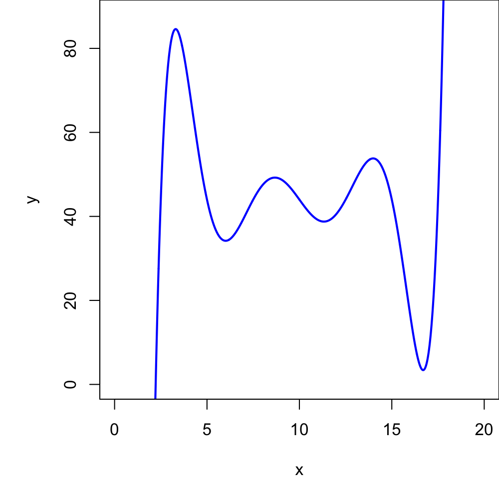

Assume this graph contains all the extrema of the function, so the end-behavior is also indicated.

1. What is the lowest possible degree of the polynomial?
2. What is the polynomial degree's parity?
3. What is the sign of the leading coefficient?

The graph contains $6$ extrema. Specifically:

- The number of minima (valley bottoms) is 3.
- The number of maxima (mountain peaks) is 3.

To have $6$ extrema, the polynomial's degree must be at least $7$. So, $n\ge 7$.

Notice, the number of extrema (6) is even. This indicates the polynomial's degree must be odd.

On the right side of the graph, as $x\to \infty$, we see the curve heads up. This tells us that the leading coefficient, $a_n$, is positive.

**BACKGROUND**

A generalized ([univariate](https://en.wikipedia.org/wiki/Univariate)) polynomial function in standard form can be expressed as:

$$y=a_nx^n+a_{n-1}x^{n-1}+\cdots+a_2x^2+a_1x+a_0$$

where $n$ represents the [degree](https://en.wikipedia.org/wiki/Degree_of_a_polynomial) of the polynomial, $a_n$ is the leading coefficient, $a_i$ is the $i^{\mathrm{th}}$-degree coefficient, $a_2$ is the quadratic coefficient, $a_1$ is the linear coefficient, and $a_0$ is the constant. It should be mentioned that $a_n\ne 0$, but the other coefficients could equal 0.

When a polynomial of degree $n$ is graphed, the **most** possible number of [extrema](https://en.wikipedia.org/wiki/Maximum_and_minimum) is $n-1$. For example, a quadratic polynomial function has one extreme, but a cubic polynomial function can have either 2 extrema or none, and a quartic (4th-degree) polynomial can have either 3 extrema or 1.

The end behavior of polynomials dictates that an even-degree polynomial will have an odd number of extrema, and an odd-degree polynomial will have an even number of extrema.

The leading coefficient's sign dictates the right-side end behavior. If as $x\to\infty$ we see $y\to\infty$, then $a_n>0$. On the other hand, if as $x\to\infty$ we see $y\to-\infty$, then $a_n<0$.

**SPECIFIC PROBLEM**

Consider the polynomial function graphed below.

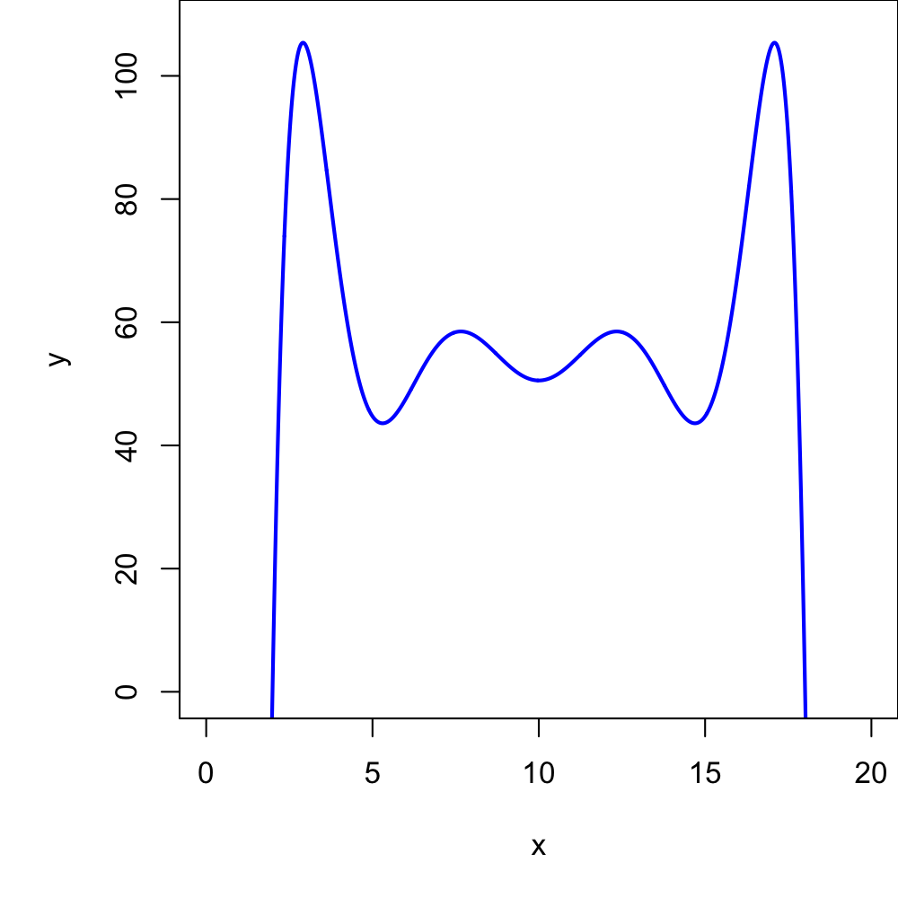

Assume this graph contains all the extrema of the function, so the end-behavior is also indicated.

1. What is the lowest possible degree of the polynomial?
2. What is the polynomial degree's parity?
3. What is the sign of the leading coefficient?

The graph contains $7$ extrema. Specifically:

- The number of minima (valley bottoms) is 3.
- The number of maxima (mountain peaks) is 4.

To have $7$ extrema, the polynomial's degree must be at least $8$. So, $n\ge 8$.

Notice, the number of extrema (7) is odd. This indicates the polynomial's degree must be even.

On the right side of the graph, as $x\to \infty$, we see the curve heads down. This tells us that the leading coefficient, $a_n$, is negative.

**BACKGROUND**

A generalized ([univariate](https://en.wikipedia.org/wiki/Univariate)) polynomial function in standard form can be expressed as:

$$y=a_nx^n+a_{n-1}x^{n-1}+\cdots+a_2x^2+a_1x+a_0$$

where $n$ represents the [degree](https://en.wikipedia.org/wiki/Degree_of_a_polynomial) of the polynomial, $a_n$ is the leading coefficient, $a_i$ is the $i^{\mathrm{th}}$-degree coefficient, $a_2$ is the quadratic coefficient, $a_1$ is the linear coefficient, and $a_0$ is the constant. It should be mentioned that $a_n\ne 0$, but the other coefficients could equal 0.

When a polynomial of degree $n$ is graphed, the **most** possible number of [extrema](https://en.wikipedia.org/wiki/Maximum_and_minimum) is $n-1$. For example, a quadratic polynomial function has one extreme, but a cubic polynomial function can have either 2 extrema or none, and a quartic (4th-degree) polynomial can have either 3 extrema or 1.

The end behavior of polynomials dictates that an even-degree polynomial will have an odd number of extrema, and an odd-degree polynomial will have an even number of extrema.

The leading coefficient's sign dictates the right-side end behavior. If as $x\to\infty$ we see $y\to\infty$, then $a_n>0$. On the other hand, if as $x\to\infty$ we see $y\to-\infty$, then $a_n<0$.

**SPECIFIC PROBLEM**

Consider the polynomial function graphed below.

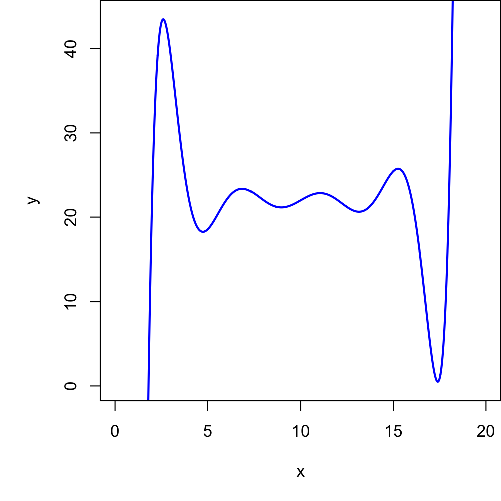

Assume this graph contains all the extrema of the function, so the end-behavior is also indicated.

1. What is the lowest possible degree of the polynomial?
2. What is the polynomial degree's parity?
3. What is the sign of the leading coefficient?

The graph contains $8$ extrema. Specifically:

- The number of minima (valley bottoms) is 4.
- The number of maxima (mountain peaks) is 4.

To have $8$ extrema, the polynomial's degree must be at least $9$. So, $n\ge 9$.

Notice, the number of extrema (8) is even. This indicates the polynomial's degree must be odd.

On the right side of the graph, as $x\to \infty$, we see the curve heads up. This tells us that the leading coefficient, $a_n$, is positive.

**BACKGROUND**

A generalized ([univariate](https://en.wikipedia.org/wiki/Univariate)) polynomial function in standard form can be expressed as:

$$y=a_nx^n+a_{n-1}x^{n-1}+\cdots+a_2x^2+a_1x+a_0$$

where $n$ represents the [degree](https://en.wikipedia.org/wiki/Degree_of_a_polynomial) of the polynomial, $a_n$ is the leading coefficient, $a_i$ is the $i^{\mathrm{th}}$-degree coefficient, $a_2$ is the quadratic coefficient, $a_1$ is the linear coefficient, and $a_0$ is the constant. It should be mentioned that $a_n\ne 0$, but the other coefficients could equal 0.

When a polynomial of degree $n$ is graphed, the **most** possible number of [extrema](https://en.wikipedia.org/wiki/Maximum_and_minimum) is $n-1$. For example, a quadratic polynomial function has one extreme, but a cubic polynomial function can have either 2 extrema or none, and a quartic (4th-degree) polynomial can have either 3 extrema or 1.

The end behavior of polynomials dictates that an even-degree polynomial will have an odd number of extrema, and an odd-degree polynomial will have an even number of extrema.

The leading coefficient's sign dictates the right-side end behavior. If as $x\to\infty$ we see $y\to\infty$, then $a_n>0$. On the other hand, if as $x\to\infty$ we see $y\to-\infty$, then $a_n<0$.

**SPECIFIC PROBLEM**

Consider the polynomial function graphed below.

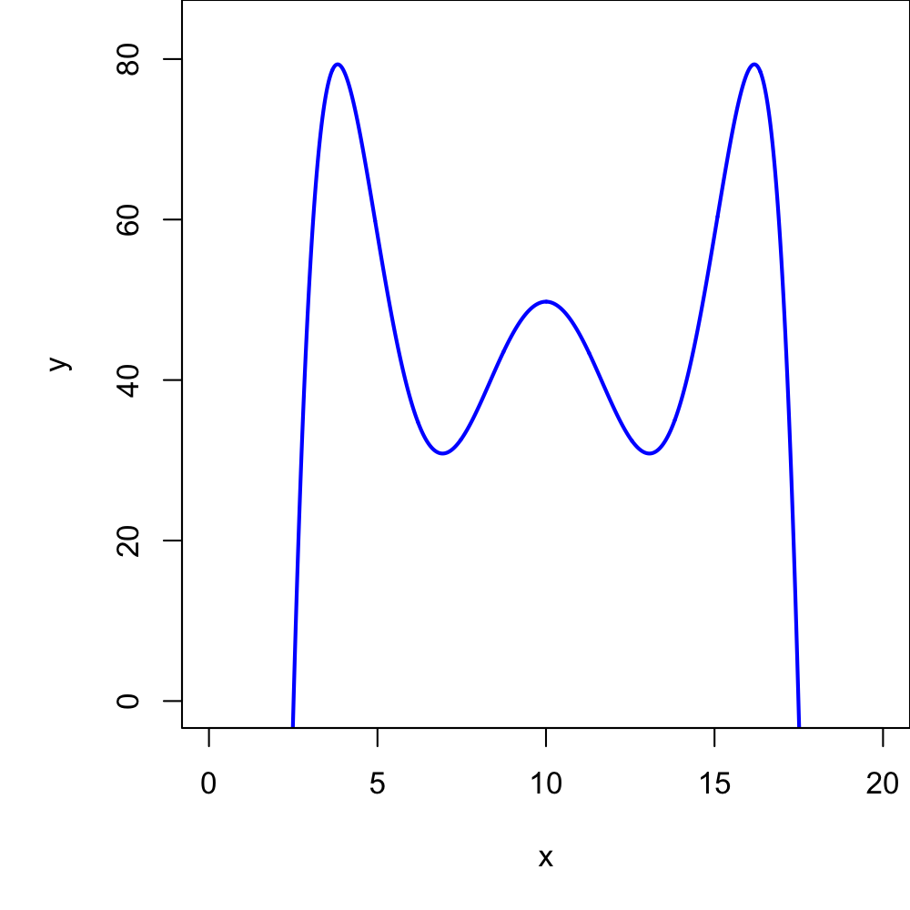

Assume this graph contains all the extrema of the function, so the end-behavior is also indicated.

1. What is the lowest possible degree of the polynomial?
2. What is the polynomial degree's parity?
3. What is the sign of the leading coefficient?

The graph contains $5$ extrema. Specifically:

- The number of minima (valley bottoms) is 2.
- The number of maxima (mountain peaks) is 3.

To have $5$ extrema, the polynomial's degree must be at least $6$. So, $n\ge 6$.

Notice, the number of extrema (5) is odd. This indicates the polynomial's degree must be even.

On the right side of the graph, as $x\to \infty$, we see the curve heads down. This tells us that the leading coefficient, $a_n$, is negative.

**BACKGROUND**

A generalized ([univariate](https://en.wikipedia.org/wiki/Univariate)) polynomial function in standard form can be expressed as:

$$y=a_nx^n+a_{n-1}x^{n-1}+\cdots+a_2x^2+a_1x+a_0$$

where $n$ represents the [degree](https://en.wikipedia.org/wiki/Degree_of_a_polynomial) of the polynomial, $a_n$ is the leading coefficient, $a_i$ is the $i^{\mathrm{th}}$-degree coefficient, $a_2$ is the quadratic coefficient, $a_1$ is the linear coefficient, and $a_0$ is the constant. It should be mentioned that $a_n\ne 0$, but the other coefficients could equal 0.

When a polynomial of degree $n$ is graphed, the **most** possible number of [extrema](https://en.wikipedia.org/wiki/Maximum_and_minimum) is $n-1$. For example, a quadratic polynomial function has one extreme, but a cubic polynomial function can have either 2 extrema or none, and a quartic (4th-degree) polynomial can have either 3 extrema or 1.

The end behavior of polynomials dictates that an even-degree polynomial will have an odd number of extrema, and an odd-degree polynomial will have an even number of extrema.

The leading coefficient's sign dictates the right-side end behavior. If as $x\to\infty$ we see $y\to\infty$, then $a_n>0$. On the other hand, if as $x\to\infty$ we see $y\to-\infty$, then $a_n<0$.

**SPECIFIC PROBLEM**

Consider the polynomial function graphed below.

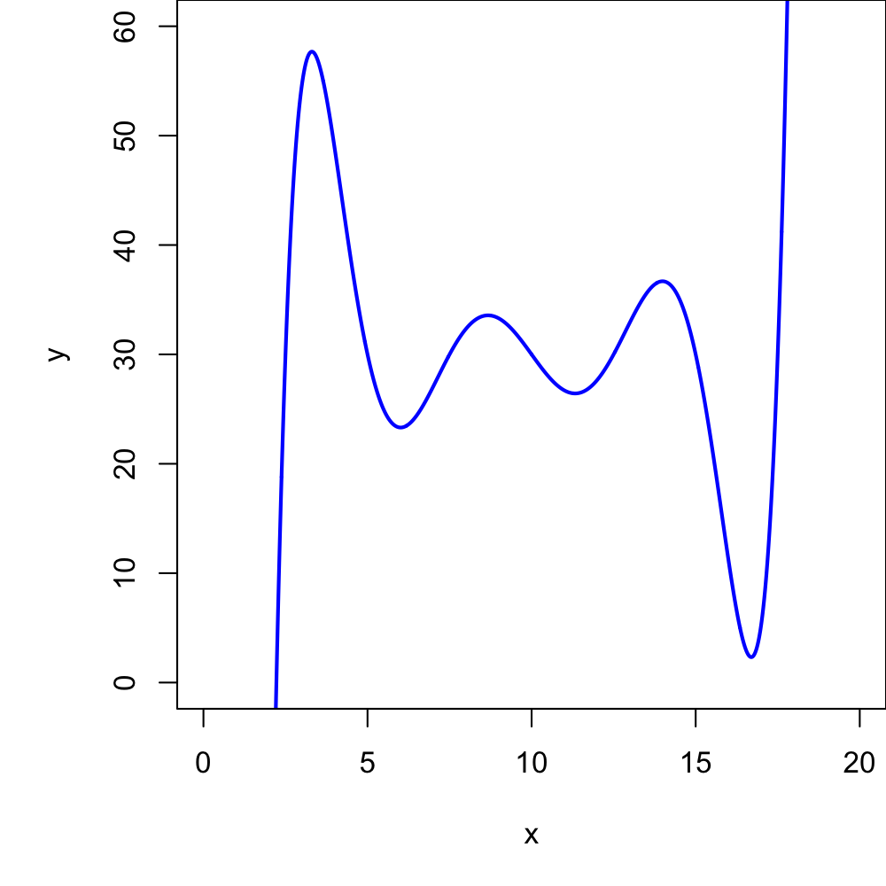

Assume this graph contains all the extrema of the function, so the end-behavior is also indicated.

1. What is the lowest possible degree of the polynomial?
2. What is the polynomial degree's parity?
3. What is the sign of the leading coefficient?

The graph contains $6$ extrema. Specifically:

- The number of minima (valley bottoms) is 3.
- The number of maxima (mountain peaks) is 3.

To have $6$ extrema, the polynomial's degree must be at least $7$. So, $n\ge 7$.

Notice, the number of extrema (6) is even. This indicates the polynomial's degree must be odd.

On the right side of the graph, as $x\to \infty$, we see the curve heads up. This tells us that the leading coefficient, $a_n$, is positive.

**BACKGROUND**

A generalized ([univariate](https://en.wikipedia.org/wiki/Univariate)) polynomial function in standard form can be expressed as:

$$y=a_nx^n+a_{n-1}x^{n-1}+\cdots+a_2x^2+a_1x+a_0$$

where $n$ represents the [degree](https://en.wikipedia.org/wiki/Degree_of_a_polynomial) of the polynomial, $a_n$ is the leading coefficient, $a_i$ is the $i^{\mathrm{th}}$-degree coefficient, $a_2$ is the quadratic coefficient, $a_1$ is the linear coefficient, and $a_0$ is the constant. It should be mentioned that $a_n\ne 0$, but the other coefficients could equal 0.

When a polynomial of degree $n$ is graphed, the **most** possible number of [extrema](https://en.wikipedia.org/wiki/Maximum_and_minimum) is $n-1$. For example, a quadratic polynomial function has one extreme, but a cubic polynomial function can have either 2 extrema or none, and a quartic (4th-degree) polynomial can have either 3 extrema or 1.

The end behavior of polynomials dictates that an even-degree polynomial will have an odd number of extrema, and an odd-degree polynomial will have an even number of extrema.

The leading coefficient's sign dictates the right-side end behavior. If as $x\to\infty$ we see $y\to\infty$, then $a_n>0$. On the other hand, if as $x\to\infty$ we see $y\to-\infty$, then $a_n<0$.

**SPECIFIC PROBLEM**

Consider the polynomial function graphed below.

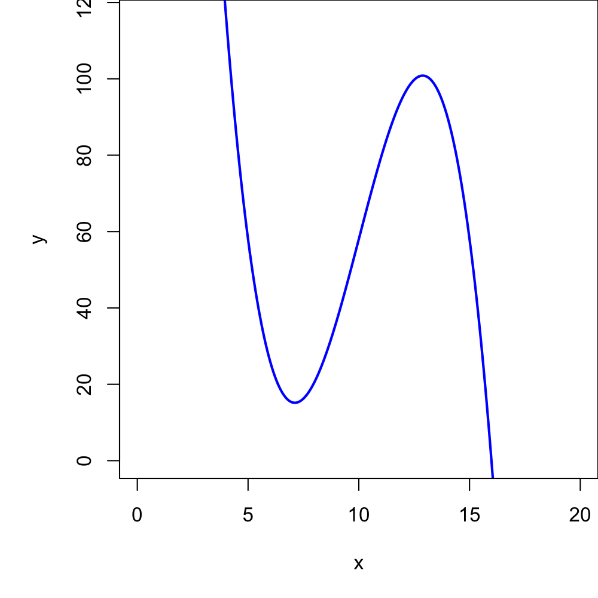

Assume this graph contains all the extrema of the function, so the end-behavior is also indicated.

1. What is the lowest possible degree of the polynomial?
2. What is the polynomial degree's parity?
3. What is the sign of the leading coefficient?

The graph contains $2$ extrema. Specifically:

- The number of minima (valley bottoms) is 1.
- The number of maxima (mountain peaks) is 1.

To have $2$ extrema, the polynomial's degree must be at least $3$. So, $n\ge 3$.

Notice, the number of extrema (2) is even. This indicates the polynomial's degree must be odd.

On the right side of the graph, as $x\to \infty$, we see the curve heads down. This tells us that the leading coefficient, $a_n$, is negative.

**BACKGROUND**

A generalized ([univariate](https://en.wikipedia.org/wiki/Univariate)) polynomial function in standard form can be expressed as:

$$y=a_nx^n+a_{n-1}x^{n-1}+\cdots+a_2x^2+a_1x+a_0$$

where $n$ represents the [degree](https://en.wikipedia.org/wiki/Degree_of_a_polynomial) of the polynomial, $a_n$ is the leading coefficient, $a_i$ is the $i^{\mathrm{th}}$-degree coefficient, $a_2$ is the quadratic coefficient, $a_1$ is the linear coefficient, and $a_0$ is the constant. It should be mentioned that $a_n\ne 0$, but the other coefficients could equal 0.

When a polynomial of degree $n$ is graphed, the **most** possible number of [extrema](https://en.wikipedia.org/wiki/Maximum_and_minimum) is $n-1$. For example, a quadratic polynomial function has one extreme, but a cubic polynomial function can have either 2 extrema or none, and a quartic (4th-degree) polynomial can have either 3 extrema or 1.

The end behavior of polynomials dictates that an even-degree polynomial will have an odd number of extrema, and an odd-degree polynomial will have an even number of extrema.

The leading coefficient's sign dictates the right-side end behavior. If as $x\to\infty$ we see $y\to\infty$, then $a_n>0$. On the other hand, if as $x\to\infty$ we see $y\to-\infty$, then $a_n<0$.

**SPECIFIC PROBLEM**

Consider the polynomial function graphed below.

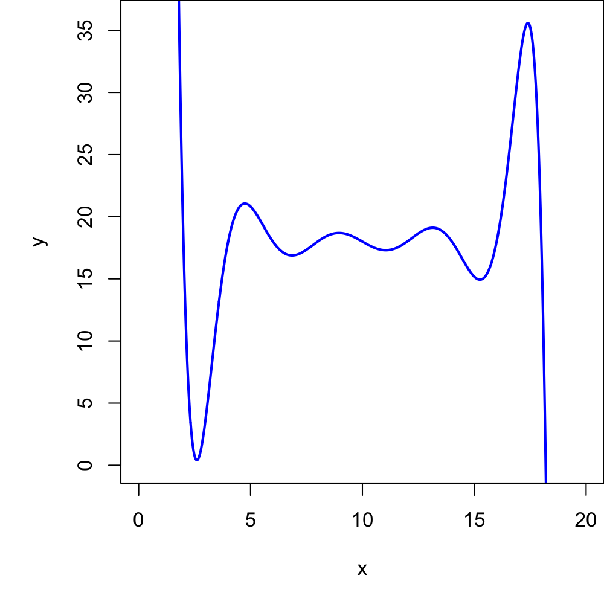

Assume this graph contains all the extrema of the function, so the end-behavior is also indicated.

1. What is the lowest possible degree of the polynomial?
2. What is the polynomial degree's parity?
3. What is the sign of the leading coefficient?

The graph contains $8$ extrema. Specifically:

- The number of minima (valley bottoms) is 4.
- The number of maxima (mountain peaks) is 4.

To have $8$ extrema, the polynomial's degree must be at least $9$. So, $n\ge 9$.

Notice, the number of extrema (8) is even. This indicates the polynomial's degree must be odd.

On the right side of the graph, as $x\to \infty$, we see the curve heads down. This tells us that the leading coefficient, $a_n$, is negative.

**BACKGROUND**

A generalized ([univariate](https://en.wikipedia.org/wiki/Univariate)) polynomial function in standard form can be expressed as:

$$y=a_nx^n+a_{n-1}x^{n-1}+\cdots+a_2x^2+a_1x+a_0$$

where $n$ represents the [degree](https://en.wikipedia.org/wiki/Degree_of_a_polynomial) of the polynomial, $a_n$ is the leading coefficient, $a_i$ is the $i^{\mathrm{th}}$-degree coefficient, $a_2$ is the quadratic coefficient, $a_1$ is the linear coefficient, and $a_0$ is the constant. It should be mentioned that $a_n\ne 0$, but the other coefficients could equal 0.

When a polynomial of degree $n$ is graphed, the **most** possible number of [extrema](https://en.wikipedia.org/wiki/Maximum_and_minimum) is $n-1$. For example, a quadratic polynomial function has one extreme, but a cubic polynomial function can have either 2 extrema or none, and a quartic (4th-degree) polynomial can have either 3 extrema or 1.

The end behavior of polynomials dictates that an even-degree polynomial will have an odd number of extrema, and an odd-degree polynomial will have an even number of extrema.

The leading coefficient's sign dictates the right-side end behavior. If as $x\to\infty$ we see $y\to\infty$, then $a_n>0$. On the other hand, if as $x\to\infty$ we see $y\to-\infty$, then $a_n<0$.

**SPECIFIC PROBLEM**

Consider the polynomial function graphed below.

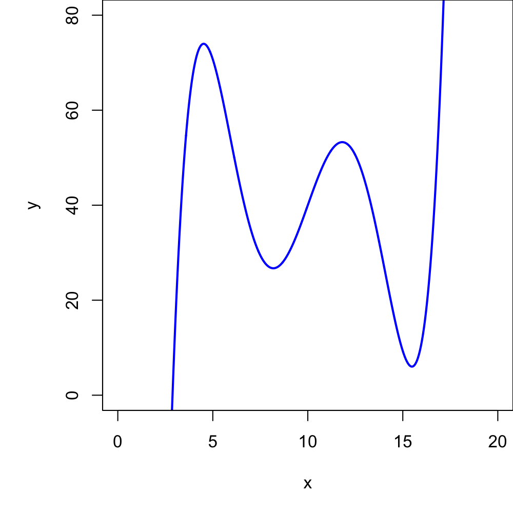

Assume this graph contains all the extrema of the function, so the end-behavior is also indicated.

1. What is the lowest possible degree of the polynomial?
2. What is the polynomial degree's parity?
3. What is the sign of the leading coefficient?

The graph contains $4$ extrema. Specifically:

- The number of minima (valley bottoms) is 2.
- The number of maxima (mountain peaks) is 2.

To have $4$ extrema, the polynomial's degree must be at least $5$. So, $n\ge 5$.

Notice, the number of extrema (4) is even. This indicates the polynomial's degree must be odd.

On the right side of the graph, as $x\to \infty$, we see the curve heads up. This tells us that the leading coefficient, $a_n$, is positive.

**BACKGROUND**

A generalized ([univariate](https://en.wikipedia.org/wiki/Univariate)) polynomial function in standard form can be expressed as:

$$y=a_nx^n+a_{n-1}x^{n-1}+\cdots+a_2x^2+a_1x+a_0$$

where $n$ represents the [degree](https://en.wikipedia.org/wiki/Degree_of_a_polynomial) of the polynomial, $a_n$ is the leading coefficient, $a_i$ is the $i^{\mathrm{th}}$-degree coefficient, $a_2$ is the quadratic coefficient, $a_1$ is the linear coefficient, and $a_0$ is the constant. It should be mentioned that $a_n\ne 0$, but the other coefficients could equal 0.

When a polynomial of degree $n$ is graphed, the **most** possible number of [extrema](https://en.wikipedia.org/wiki/Maximum_and_minimum) is $n-1$. For example, a quadratic polynomial function has one extreme, but a cubic polynomial function can have either 2 extrema or none, and a quartic (4th-degree) polynomial can have either 3 extrema or 1.

The end behavior of polynomials dictates that an even-degree polynomial will have an odd number of extrema, and an odd-degree polynomial will have an even number of extrema.

The leading coefficient's sign dictates the right-side end behavior. If as $x\to\infty$ we see $y\to\infty$, then $a_n>0$. On the other hand, if as $x\to\infty$ we see $y\to-\infty$, then $a_n<0$.

**SPECIFIC PROBLEM**

Consider the polynomial function graphed below.

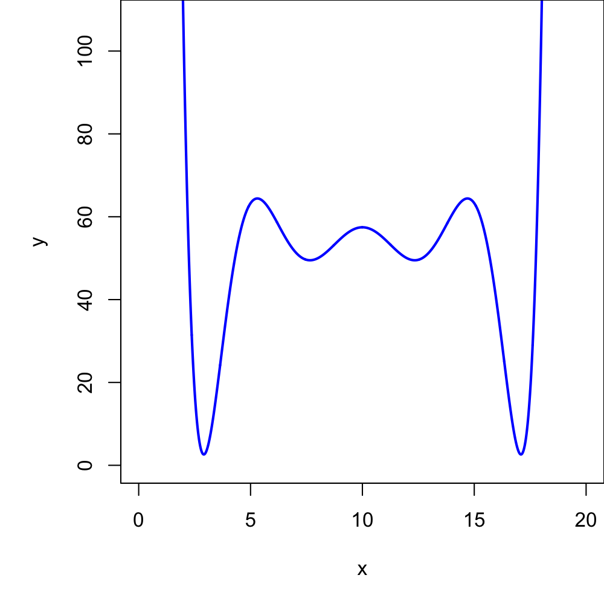

Assume this graph contains all the extrema of the function, so the end-behavior is also indicated.

1. What is the lowest possible degree of the polynomial?
2. What is the polynomial degree's parity?
3. What is the sign of the leading coefficient?

The graph contains $7$ extrema. Specifically:

- The number of minima (valley bottoms) is 4.
- The number of maxima (mountain peaks) is 3.

To have $7$ extrema, the polynomial's degree must be at least $8$. So, $n\ge 8$.

Notice, the number of extrema (7) is odd. This indicates the polynomial's degree must be even.

On the right side of the graph, as $x\to \infty$, we see the curve heads up. This tells us that the leading coefficient, $a_n$, is positive.

**BACKGROUND**

A generalized ([univariate](https://en.wikipedia.org/wiki/Univariate)) polynomial function in standard form can be expressed as:

$$y=a_nx^n+a_{n-1}x^{n-1}+\cdots+a_2x^2+a_1x+a_0$$

where $n$ represents the [degree](https://en.wikipedia.org/wiki/Degree_of_a_polynomial) of the polynomial, $a_n$ is the leading coefficient, $a_i$ is the $i^{\mathrm{th}}$-degree coefficient, $a_2$ is the quadratic coefficient, $a_1$ is the linear coefficient, and $a_0$ is the constant. It should be mentioned that $a_n\ne 0$, but the other coefficients could equal 0.

When a polynomial of degree $n$ is graphed, the **most** possible number of [extrema](https://en.wikipedia.org/wiki/Maximum_and_minimum) is $n-1$. For example, a quadratic polynomial function has one extreme, but a cubic polynomial function can have either 2 extrema or none, and a quartic (4th-degree) polynomial can have either 3 extrema or 1.

The end behavior of polynomials dictates that an even-degree polynomial will have an odd number of extrema, and an odd-degree polynomial will have an even number of extrema.

The leading coefficient's sign dictates the right-side end behavior. If as $x\to\infty$ we see $y\to\infty$, then $a_n>0$. On the other hand, if as $x\to\infty$ we see $y\to-\infty$, then $a_n<0$.

**SPECIFIC PROBLEM**

Consider the polynomial function graphed below.

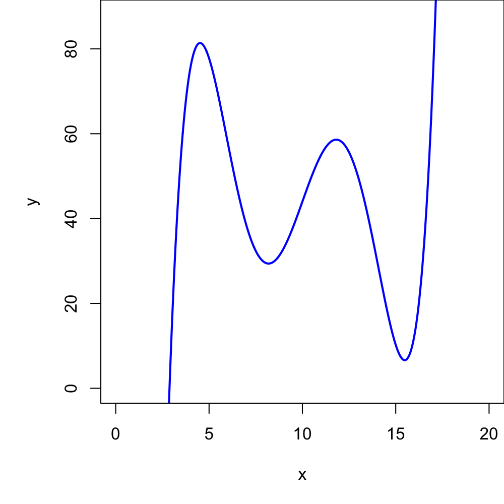

Assume this graph contains all the extrema of the function, so the end-behavior is also indicated.

1. What is the lowest possible degree of the polynomial?
2. What is the polynomial degree's parity?
3. What is the sign of the leading coefficient?

The graph contains $4$ extrema. Specifically:

- The number of minima (valley bottoms) is 2.
- The number of maxima (mountain peaks) is 2.

To have $4$ extrema, the polynomial's degree must be at least $5$. So, $n\ge 5$.

Notice, the number of extrema (4) is even. This indicates the polynomial's degree must be odd.

On the right side of the graph, as $x\to \infty$, we see the curve heads up. This tells us that the leading coefficient, $a_n$, is positive.

**BACKGROUND**

A generalized ([univariate](https://en.wikipedia.org/wiki/Univariate)) polynomial function in standard form can be expressed as:

$$y=a_nx^n+a_{n-1}x^{n-1}+\cdots+a_2x^2+a_1x+a_0$$

where $n$ represents the [degree](https://en.wikipedia.org/wiki/Degree_of_a_polynomial) of the polynomial, $a_n$ is the leading coefficient, $a_i$ is the $i^{\mathrm{th}}$-degree coefficient, $a_2$ is the quadratic coefficient, $a_1$ is the linear coefficient, and $a_0$ is the constant. It should be mentioned that $a_n\ne 0$, but the other coefficients could equal 0.

When a polynomial of degree $n$ is graphed, the **most** possible number of [extrema](https://en.wikipedia.org/wiki/Maximum_and_minimum) is $n-1$. For example, a quadratic polynomial function has one extreme, but a cubic polynomial function can have either 2 extrema or none, and a quartic (4th-degree) polynomial can have either 3 extrema or 1.

The end behavior of polynomials dictates that an even-degree polynomial will have an odd number of extrema, and an odd-degree polynomial will have an even number of extrema.

The leading coefficient's sign dictates the right-side end behavior. If as $x\to\infty$ we see $y\to\infty$, then $a_n>0$. On the other hand, if as $x\to\infty$ we see $y\to-\infty$, then $a_n<0$.

**SPECIFIC PROBLEM**

Consider the polynomial function graphed below.

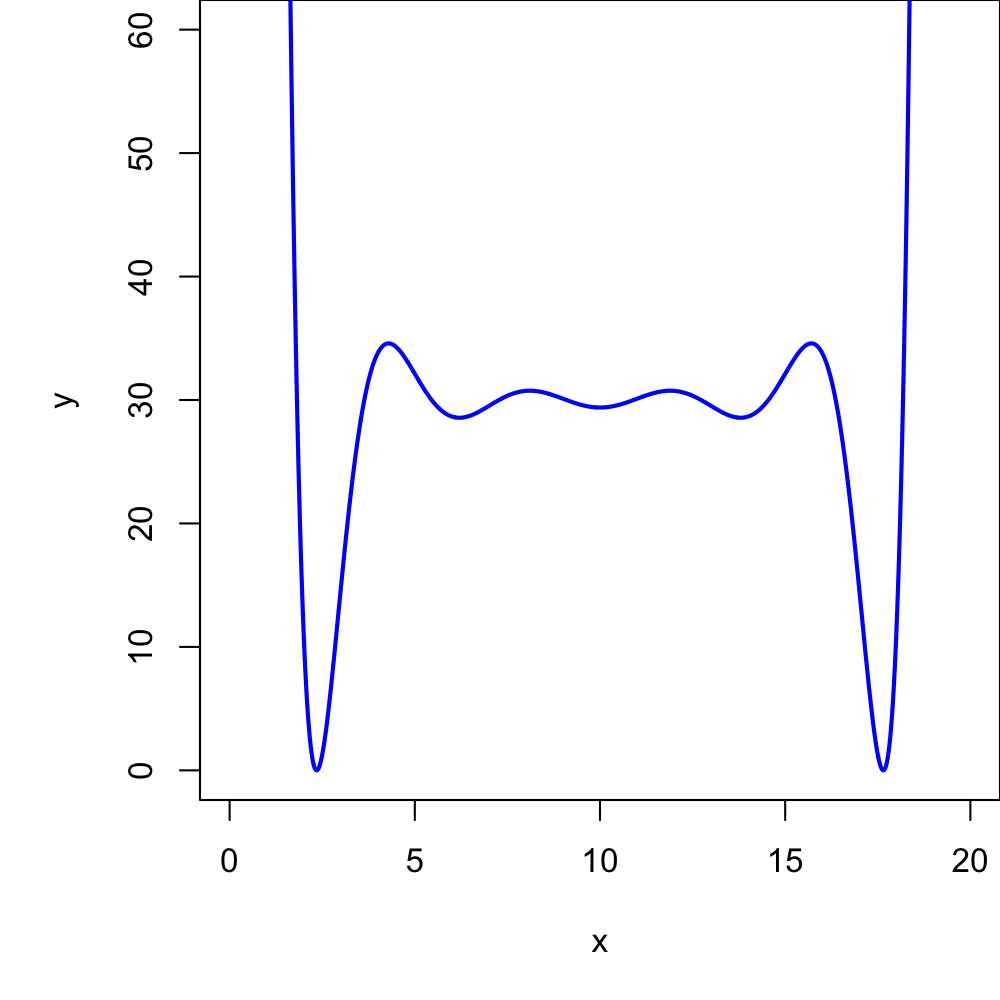

Assume this graph contains all the extrema of the function, so the end-behavior is also indicated.

1. What is the lowest possible degree of the polynomial?
2. What is the polynomial degree's parity?
3. What is the sign of the leading coefficient?

The graph contains $9$ extrema. Specifically:

- The number of minima (valley bottoms) is 5.
- The number of maxima (mountain peaks) is 4.

To have $9$ extrema, the polynomial's degree must be at least $10$. So, $n\ge 10$.

Notice, the number of extrema (9) is odd. This indicates the polynomial's degree must be even.

On the right side of the graph, as $x\to \infty$, we see the curve heads up. This tells us that the leading coefficient, $a_n$, is positive.

**BACKGROUND**

A generalized ([univariate](https://en.wikipedia.org/wiki/Univariate)) polynomial function in standard form can be expressed as:

$$y=a_nx^n+a_{n-1}x^{n-1}+\cdots+a_2x^2+a_1x+a_0$$

where $n$ represents the [degree](https://en.wikipedia.org/wiki/Degree_of_a_polynomial) of the polynomial, $a_n$ is the leading coefficient, $a_i$ is the $i^{\mathrm{th}}$-degree coefficient, $a_2$ is the quadratic coefficient, $a_1$ is the linear coefficient, and $a_0$ is the constant. It should be mentioned that $a_n\ne 0$, but the other coefficients could equal 0.

When a polynomial of degree $n$ is graphed, the **most** possible number of [extrema](https://en.wikipedia.org/wiki/Maximum_and_minimum) is $n-1$. For example, a quadratic polynomial function has one extreme, but a cubic polynomial function can have either 2 extrema or none, and a quartic (4th-degree) polynomial can have either 3 extrema or 1.

The end behavior of polynomials dictates that an even-degree polynomial will have an odd number of extrema, and an odd-degree polynomial will have an even number of extrema.

The leading coefficient's sign dictates the right-side end behavior. If as $x\to\infty$ we see $y\to\infty$, then $a_n>0$. On the other hand, if as $x\to\infty$ we see $y\to-\infty$, then $a_n<0$.

**SPECIFIC PROBLEM**

Consider the polynomial function graphed below.

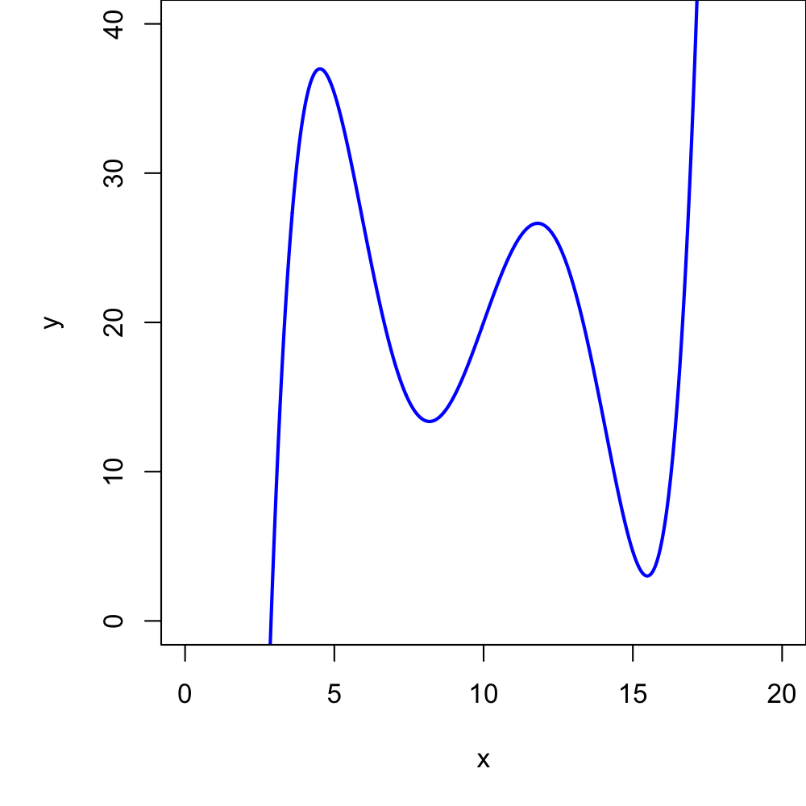

Assume this graph contains all the extrema of the function, so the end-behavior is also indicated.

1. What is the lowest possible degree of the polynomial?
2. What is the polynomial degree's parity?
3. What is the sign of the leading coefficient?

The graph contains $4$ extrema. Specifically:

- The number of minima (valley bottoms) is 2.
- The number of maxima (mountain peaks) is 2.

To have $4$ extrema, the polynomial's degree must be at least $5$. So, $n\ge 5$.

Notice, the number of extrema (4) is even. This indicates the polynomial's degree must be odd.

On the right side of the graph, as $x\to \infty$, we see the curve heads up. This tells us that the leading coefficient, $a_n$, is positive.